# Praca domowa 3

Piotr Obarski

Modele liniowe i mieszane

### Simulate two datasets, 1000 observations each. Create the first dataset in a way to pass all diagnostic plots (so, all assumptions are valid). Create the second dataset in order to fail with at least 3 diagnostic datasets (e.g. with high Cook distances, non homogeneous variance of residuals, so on).

### Show diagnostic plots for both simulated datasets.

Po wygenerowaniu danych, na wykresach diagnostycznych będę sprawdzać, czy testy diagnostyczne są spełnione, więc od razu zrobię 1. i 2. punkt z pracy domowej.

Jeśli zależność pomiędzy zmiennymi jest liniowa model powinnien być całkowicie dopasowany. Zatem zróbmy właśnie w ten sposób.

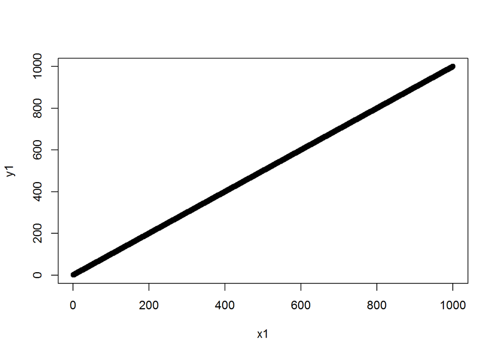

```r
library(ggplot2)
library(lmtest)
x1<-c(1:1000)
y1<-x1
dataset1<-data.frame(x1,y1)
model<-lm(y1~x1, data=dataset1)
plot(y1~x1, data=dataset1)
```

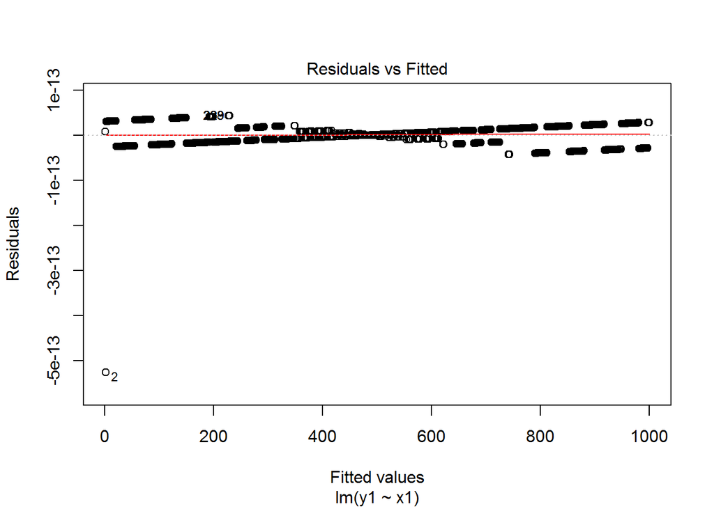

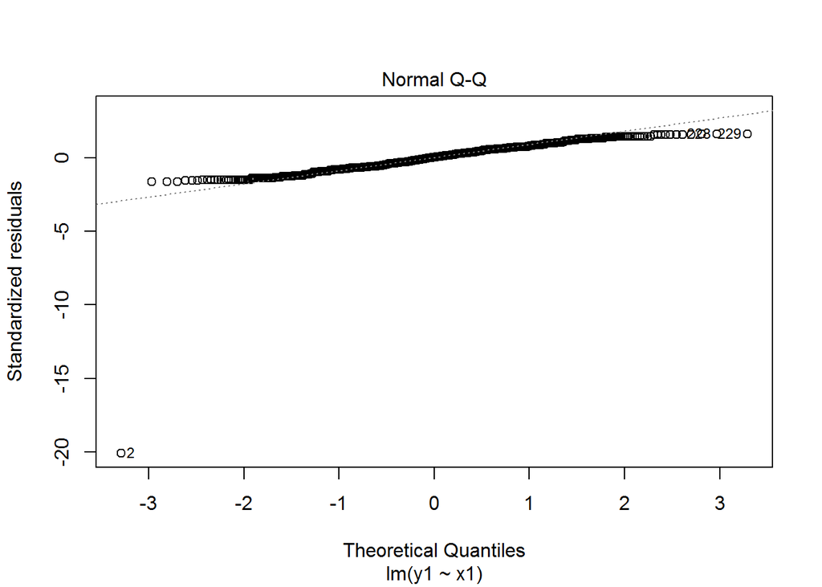

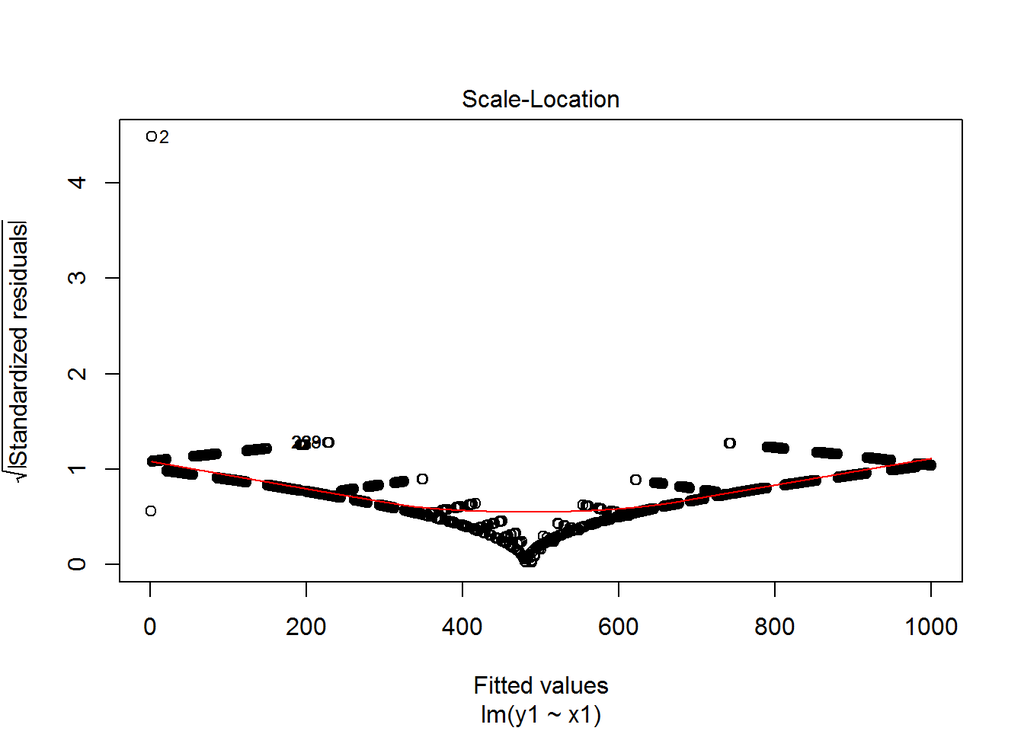

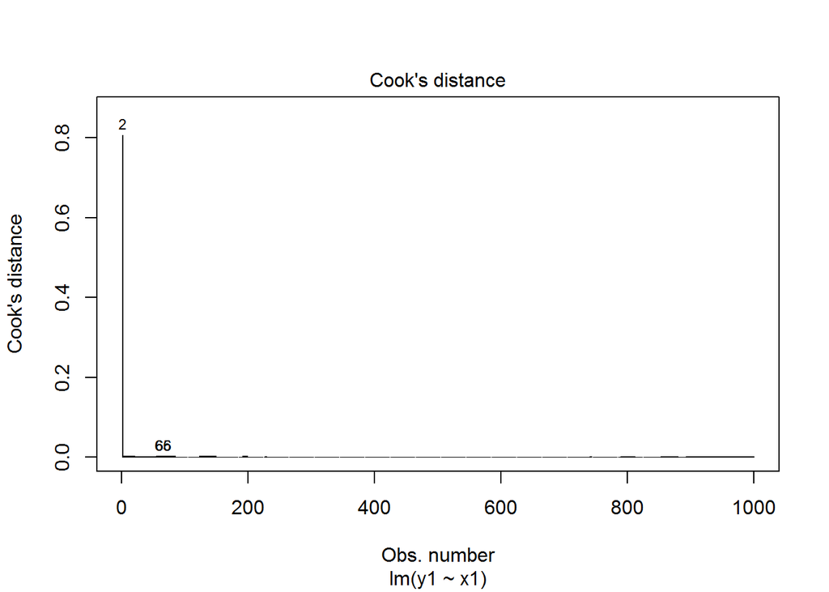

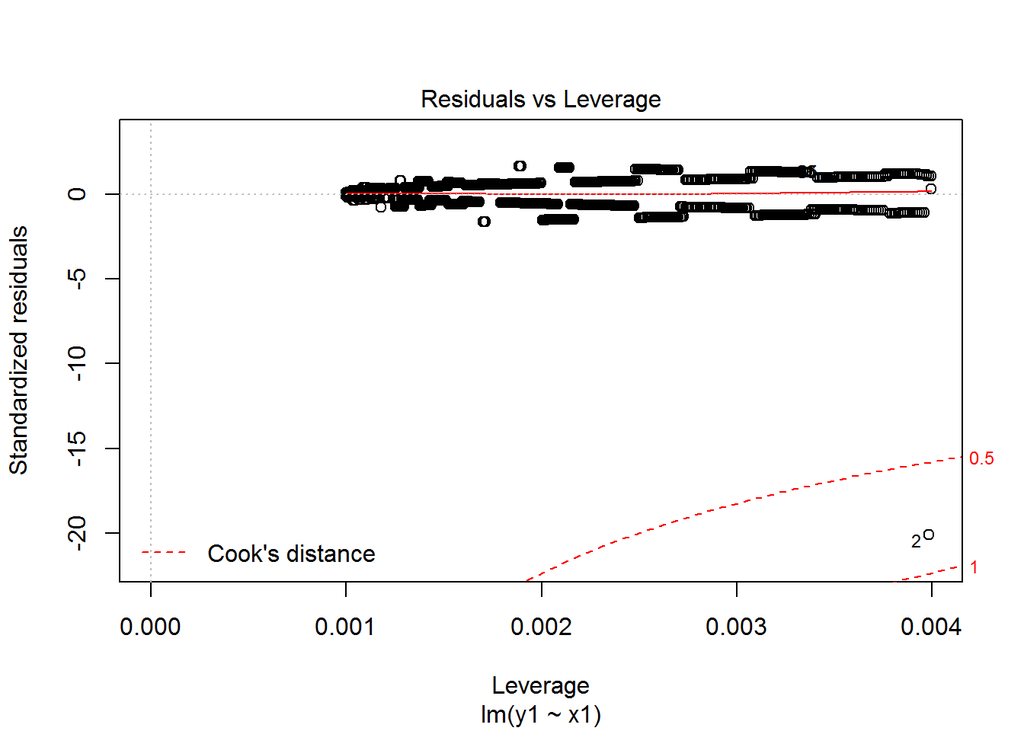

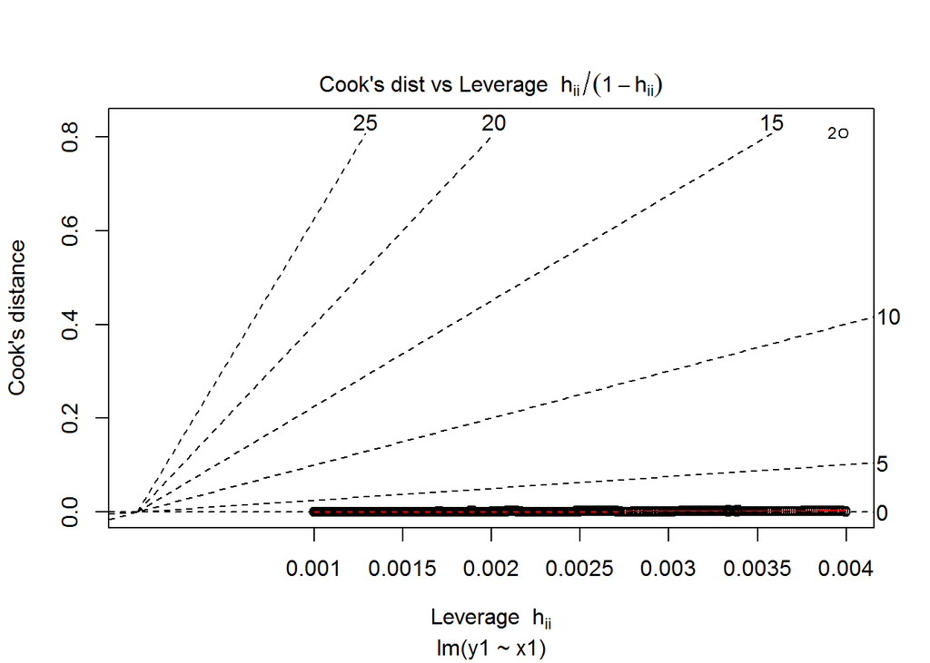

```r
plot(model, which=1:6)
```

```r
model$residuals[1:20]
```

```
##             1             2             3             4             5
##  8.197303e-15 -5.265059e-13  3.066948e-14  3.072429e-14  3.077909e-14
##             6             7             8             9            10
##  3.083389e-14  3.088869e-14  3.094350e-14  3.099830e-14  3.105310e-14
##            11            12            13            14            15
##  3.110790e-14  3.116271e-14  3.121751e-14  3.127231e-14  3.132711e-14
##            16            17            18            19            20
##  3.138192e-14  3.143672e-14  3.149152e-14  3.154633e-14  3.160113e-14
```

Widać na wykresach diagnostycznych, że model jest dobry. Co ciekawe wykresy nie są całkowicie zdegenerowane i nie są “perfekcyjne”, a późniejsze spojrzenie na residua pokazuje, że są one bliskie 0, a nie tak jak powinny być równe 0.

Żeby wygenerować drugi zbiór danych, staram się zrobić coś, żeby zależność nie była liniowa.

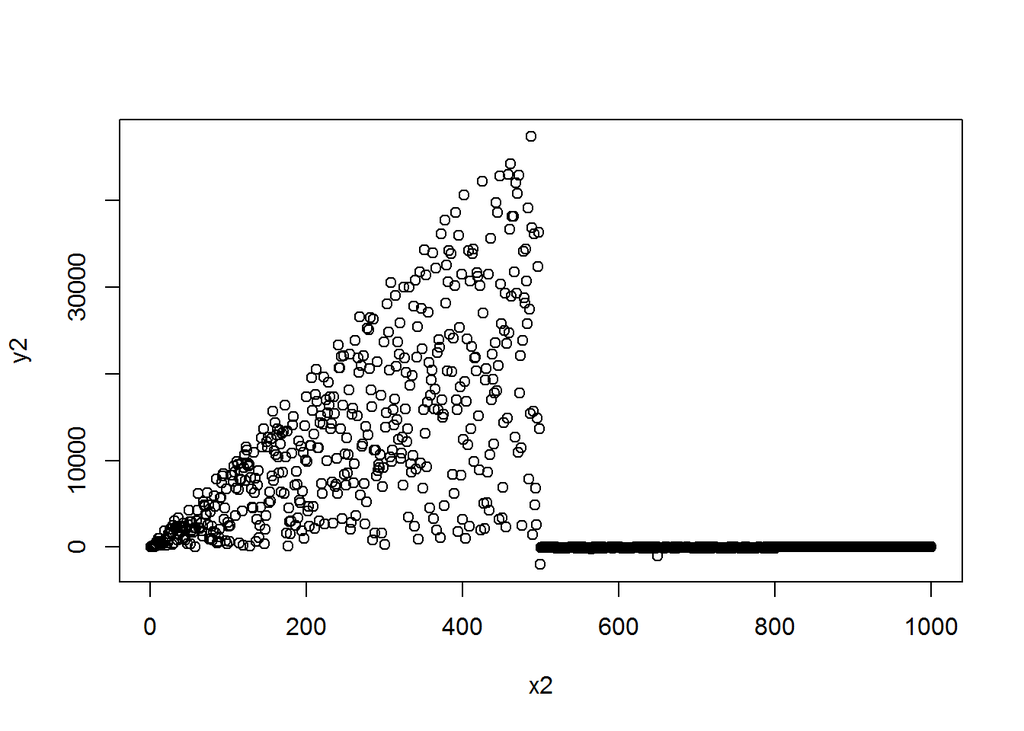

```r
x2<-x1
y2<-0
y2[1:500]<-(runif(500, 1, 100)+rnorm(500)*2)*x2[1:500]
y2[501:800]<- -runif(300, 1, 100)+rnorm(300)*40
y2[801:1000]<- runif(200)+rnorm(200)
y2[500]<--2000
y2[650]<- -1000
dataset2<-data.frame(x2,y2)
model2<-lm(y2~x2, data=dataset2)
plot(y2~x2, data=dataset2)
```

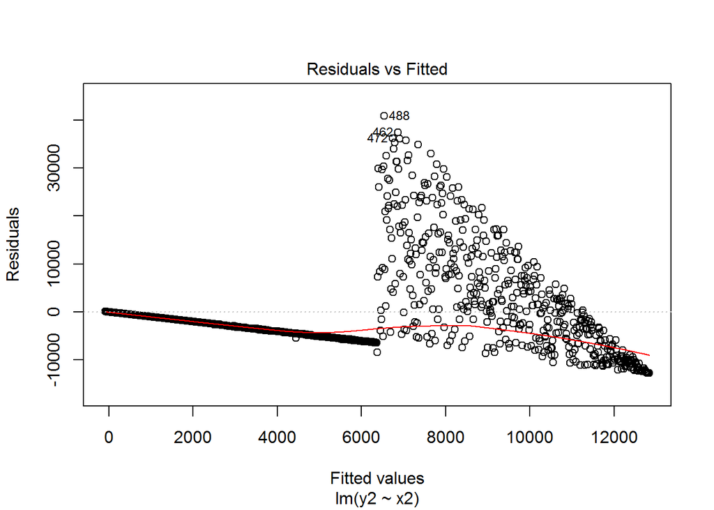

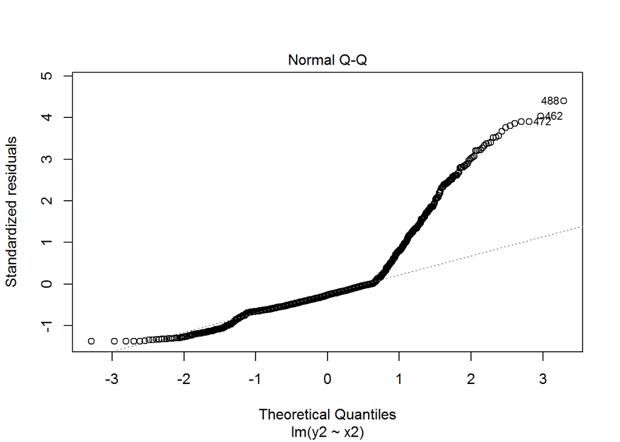

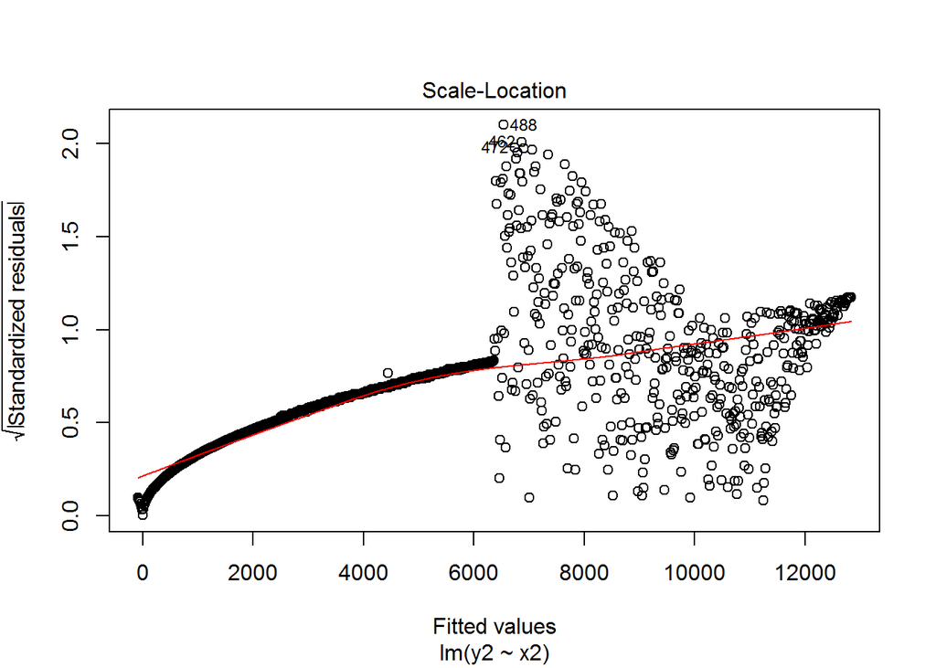

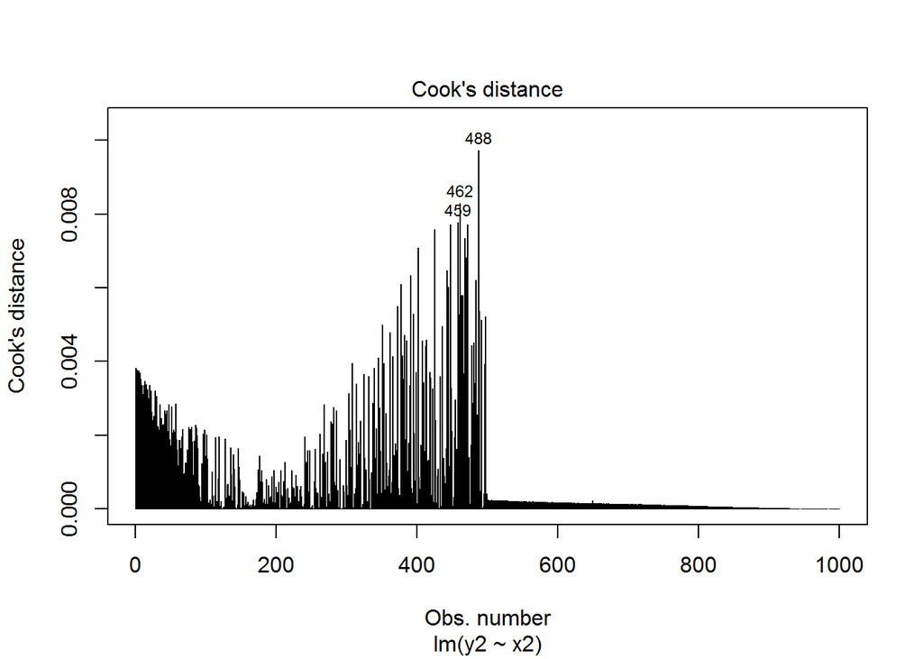

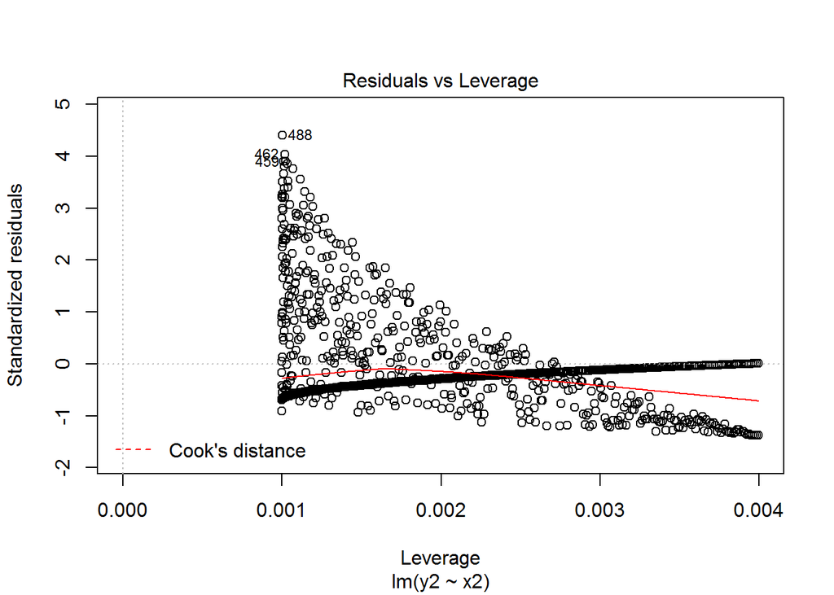

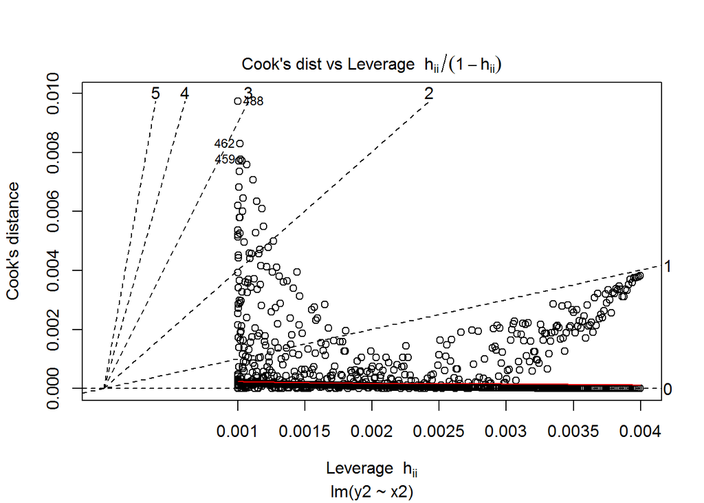

```r
plot(model2, which=1:6)
```

Na wykresach widać, że rzeczywiście nie ma zależności liniowej, a wykresy diagnostyczne potwierdzają tezę, że model jest zły. Jeszcze zrobię wykresy diagnostyczne obok siebie, żeby je porównać.

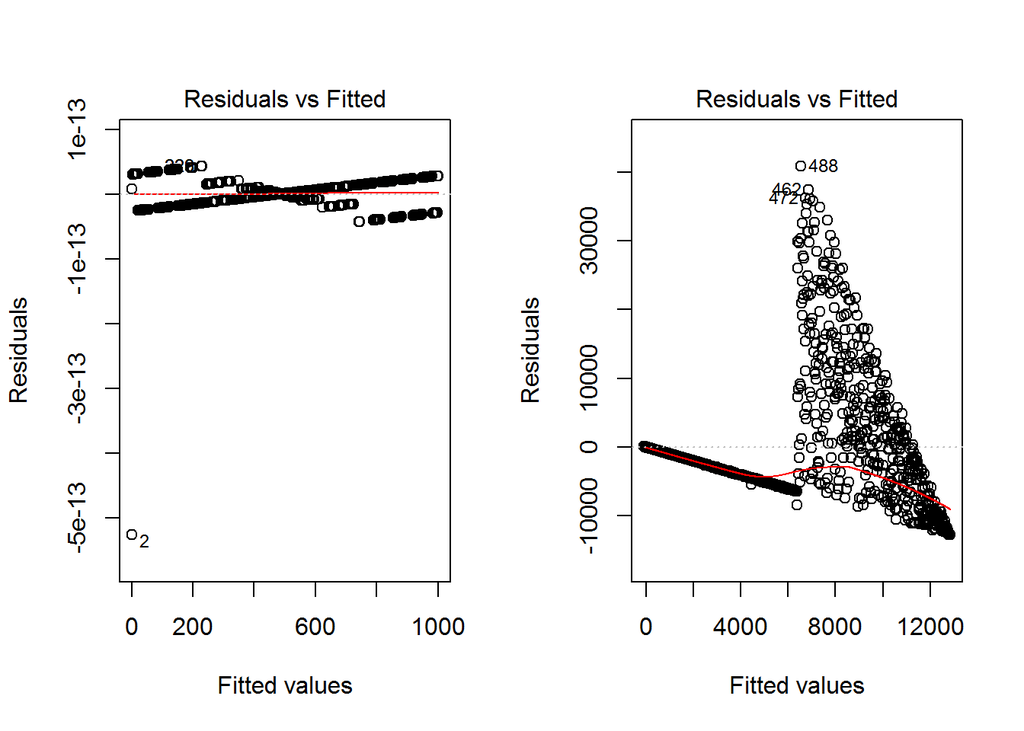

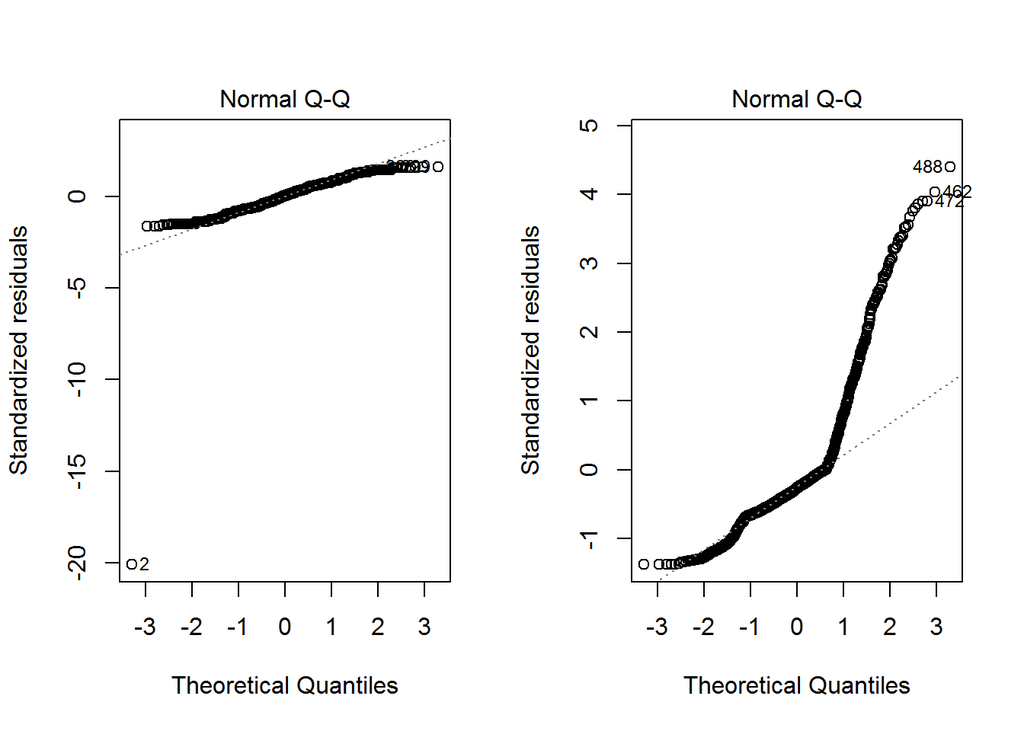

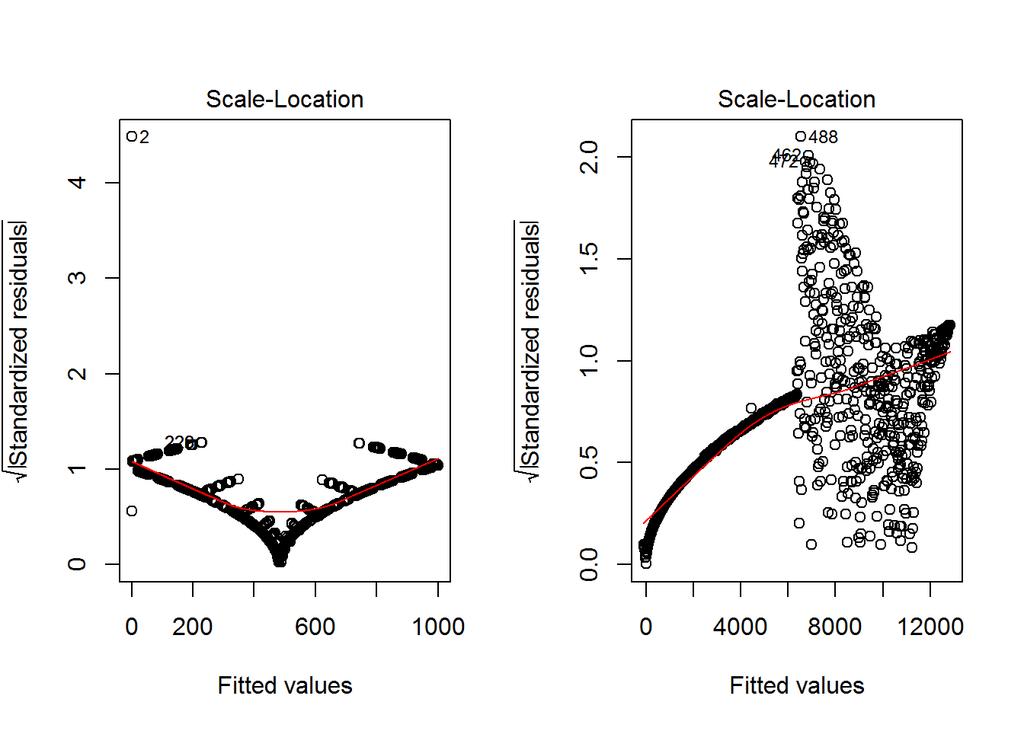

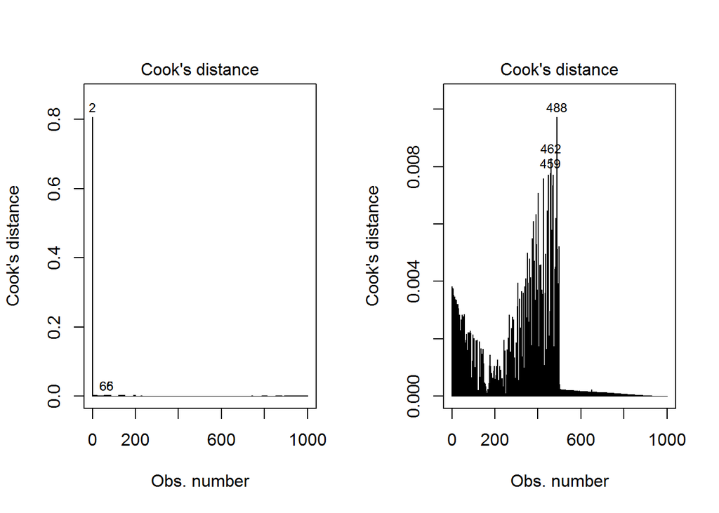

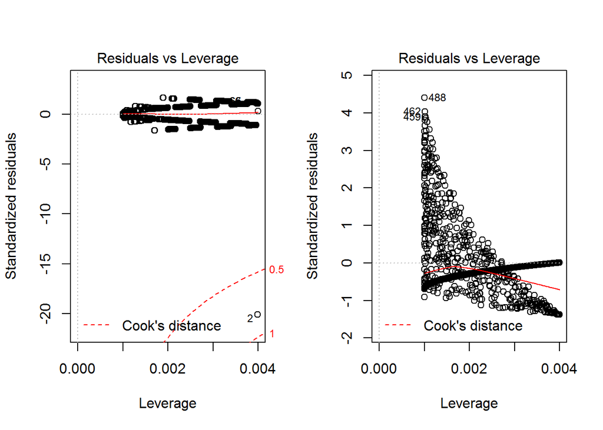

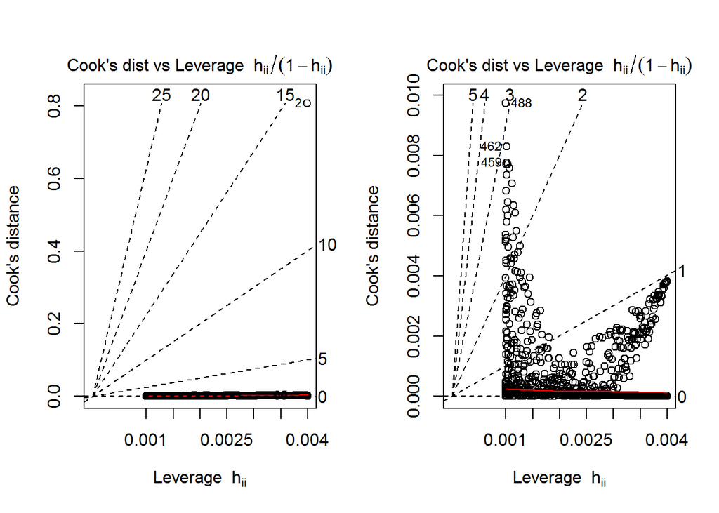

```r
par(mfrow=c(1,2))
for(i in 1:6){
  plot(model, which=i)
  plot(model2, which=i)
}
```

```r
par(mfrow=c(1,1))
```

### Choose three tests for model diagnostic (note, you should not choose the same three tests as other students. If your Submission will have same diagnostic tests as other already submitted home work then your homework will be rejected. )

Sprawdzę:  
* normalność standaryzowanych reszt  
* liniowość testem Rainbow  
* homogeniczność wariancji testem Harrisona-McCabe’a

### For each test create two simulated datasets. One that passes the given test and one that does not (e.g. simulate data with heterogeneous variance)

### Present results from diagnostic tests, show p-values for both datasets.

Do testowania normalności reszt użyję zbiorów danych z pierwszej części zadania.

```r
shapiro.test(rstandard(model))
```

```
##
##  Shapiro-Wilk normality test
##
## data:  rstandard(model)
## W = 0.69056, p-value < 2.2e-16
```

```r
shapiro.test(rstandard(model2))
```

```
##
##  Shapiro-Wilk normality test
##
## data:  rstandard(model2)
## W = 0.81147, p-value < 2.2e-16
```

Spotkało mnie tutaj niemiłe zaskoczenie, gdyż jednak model, który był testowany jako pierwszy nie ma reszt rozłożonych normalnie, mimo że jest idealna zależność liniowa. Dodam zatem do y1 z dataset1 trochę zaburzenia normalnego i powtórzę testy.

```r
y3<-y1+rnorm(1000)*10
dataset3<-data.frame(x1,y3)
model<-lm(y3~x1, data=dataset3)
shapiro.test(rstandard(model))
```

```
##
##  Shapiro-Wilk normality test
##
## data:  rstandard(model)
## W = 0.99882, p-value = 0.7689
```

```r
shapiro.test(rstandard(model2))
```

```
##
##  Shapiro-Wilk normality test
##
## data:  rstandard(model2)
## W = 0.81147, p-value < 2.2e-16
```

Widać, że p-value w pierwszym przypadku jest duże, w drugim małe, co oznacza, że pierwszy test został pomyślnie zakończony, w przeciwieństwie do drugiego.

W teście Harrisona-McCabe’a użyję tych samych danych co powyżej, jednak w dataset2 zamienię zmienną objaśnianą ze zmienną objaśniającą.

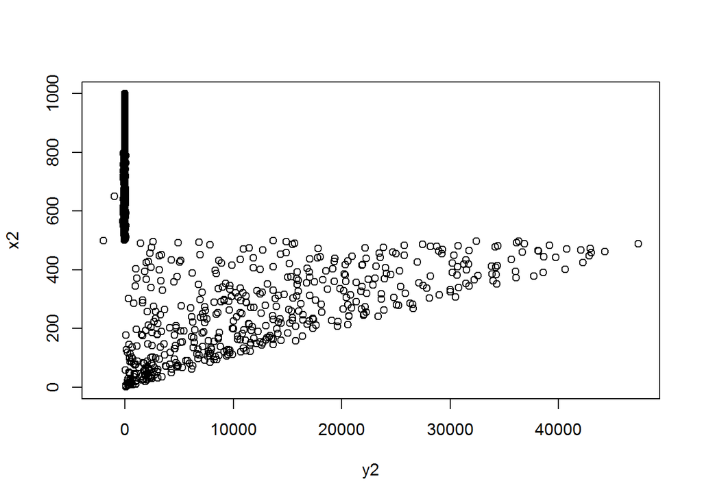

```r
plot(x2~y2, data=dataset2)
```

```r
par(mfrow=c(1,2))
hmctest(y3~x1, order.by=~x1, data = dataset3, plot=TRUE)
```

```
##
##  Harrison-McCabe test
##
## data:  y3 ~ x1
## HMC = 0.48371, p-value = 0.24
```

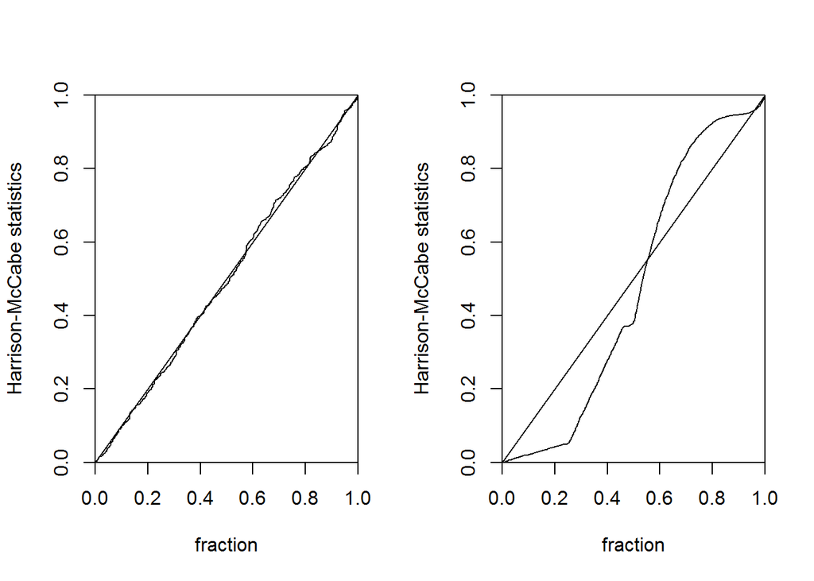

```
##
##  Harrison-McCabe test
##
## data:  x2 ~ y2
## HMC = 0.38144, p-value < 2.2e-16
```

```r
hmctest(x2~y2, order.by=~y2, data = dataset2, plot=TRUE)
```

```r
par(mfrow=c(1,1))
```

W pierwszym teście wysoka wartość p-value sugeruje, że wariancje epislonów są homogeniczne, w drugim wręcz przeciwnie.

Teraz testuję liniowość testem Rainbow. Za zbiór danych który ma przejść test przyjmuję dataset3. Lekko zmodyfikuję zbiór dataset2 i on będzie tym, który testu nie przejdzie.

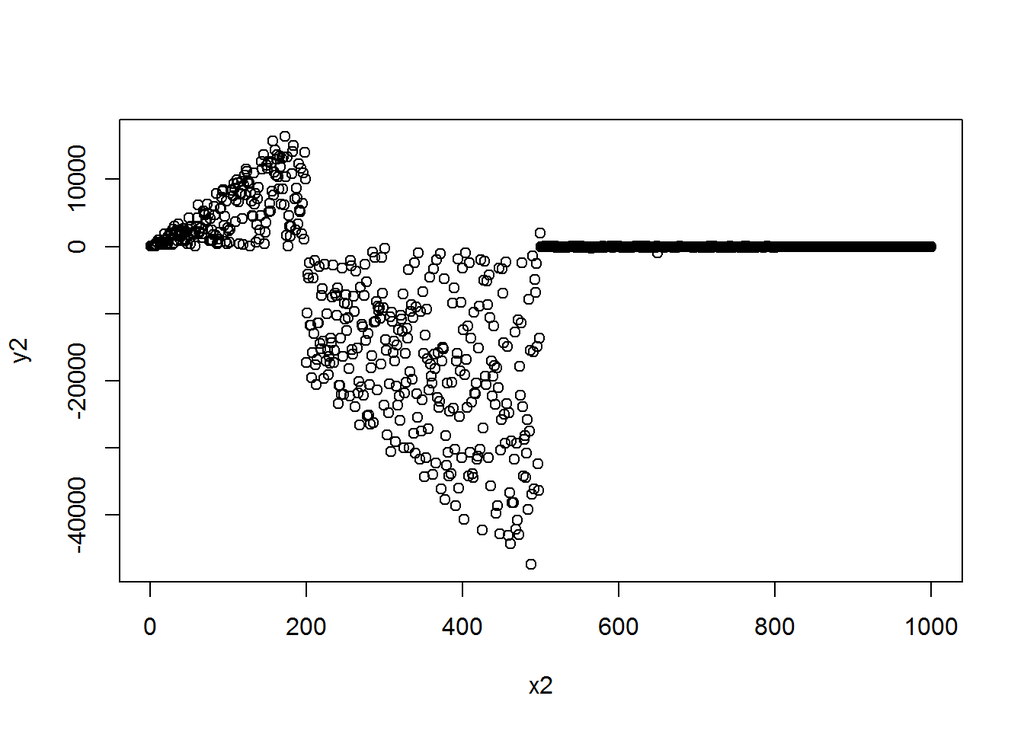

```r
dataset2$y2[200:500]<- -dataset2$y2[200:500]
plot(y2~x2, data=dataset2)
```

```r
raintest(y3~x1, order.by=~x1, data = dataset3)
```

```
##
##  Rainbow test
##
## data:  y3 ~ x1
## Rain = 0.94815, df1 = 500, df2 = 498, p-value = 0.7239
```

```r
raintest(y2~x2, order.by=~x2, data = dataset2)
```

```
##
##  Rainbow test
##
## data:  y2 ~ x2
## Rain = 1.4222, df1 = 500, df2 = 498, p-value = 4.409e-05
```

Rzeczywiście wartości p-value potwierdzają, że się dzieje tak jak zapowiedziałem.